# Introduction

This week in class, we looked at a particular technique for non-linear regression: the Geneneralized Additive Model, or GAM. In this tutorial, we will explore a particular package for fitting GAM’s in the R language, the [`mgcv`](https://cran.r-project.org/web/packages/mgcv/index.html) package.

We will explore a little bit of the theory, fit some models and demonstrate how to work with the fitted model objects in R.

To work with the code in this tutorial, you will need to install the `mgcv` package and the [`tidymv` package](https://github.com/stefanocoretta/tidymv)

```r
# install the mgcv package
install.packages('mgcv')
install.packages('tidymv')
```

## Introduction to GAMs

A generalized additive model is a generalized linear model where the linear predictor includes a sum of smoothed functions of the covariates.

For example, we might see something like

$$g(\mu_i) = X_i\theta + f_1(x_{1i}) + f_2(x_{2i}) + + f_1(x_{3i}, x_{4i})$$

Where

$$\mu_i = E(Y_i) \text{ and } Y_i \sim \text{ some exponential family member}$$
In the above

- $Y_i$ is the response variable
- $X_i$ is a row of the model matrix for any strictly parametric model components
- $\theta$ is the parameter vector associated with the effects of $X$
- $f_1$, $f_2$, and $f_3$ are smoothed functions of the covariates $x_1$, $x_2$, and $x_3$ and $x_4$ respectively.

You can imagine the flexibility a model like this allows. You can input variables in all the ways we did with regular regression models - categorical, continuous, interactions - but can now introduce smooth function terms.

## GAMs in practice

We are going to look at the cherry tree data found in the data folder.

The cherry tree data provides the diameter, height and volume measurements of the timber in 31 felled black cherry trees.

```r
# load the required R packages
library(tidyverse)
library(gt)
library(mgcv)

# read in the data
trees <- readr::read_csv('data/cherry-trees.csv')

trees %>%
  head() %>%
  gt() %>%
  tab_header(title = "Cherry Trees data",
             subtitle = "First 6 observations")
```

Cherry Trees data

First 6 observations

| diameter | height | volume |
| --- | --- | --- |
| 8.3 | 70 | 10.3 |
| 8.6 | 65 | 10.3 |
| 8.8 | 63 | 10.2 |
| 10.5 | 72 | 16.4 |
| 10.7 | 81 | 18.8 |
| 10.8 | 83 | 19.7 |

The data contains the following variables:

- diameter: tree diameter in inches
- height: tree height in feet
- volume: tree volume in cubic feet

We are going to model the log volume of a tree as a function of its height and girth.

Lets begin with a basic description of the data and some plots.

```r
# summarize each variable
trees %>%
  pivot_longer(everything(), names_to = "variable",
               values_to = "value") %>%
  group_by(variable) %>%
  summarize_if(is.numeric,
    .funs = c("n_distinct", # the number of  unique values
             "min", # the minimum value
             "max", # the maximum value
             "mean", # the mean
             "median", # the median value
             "sd")
  ) %>%
  gt() %>%
  tab_header(title = "Summary statistics for the Cherry Tree data")
```

Summary statistics for the Cherry Tree data

| variable | n_distinct | min | max | mean | median | sd |
| --- | --- | --- | --- | --- | --- | --- |
| diameter | 27 | 8.3 | 20.6 | 13.24839 | 12.9 | 3.138139 |
| height | 21 | 63.0 | 87.0 | 76.00000 | 76.0 | 6.371813 |
| volume | 30 | 10.2 | 77.0 | 30.17097 | 24.2 | 16.437846 |

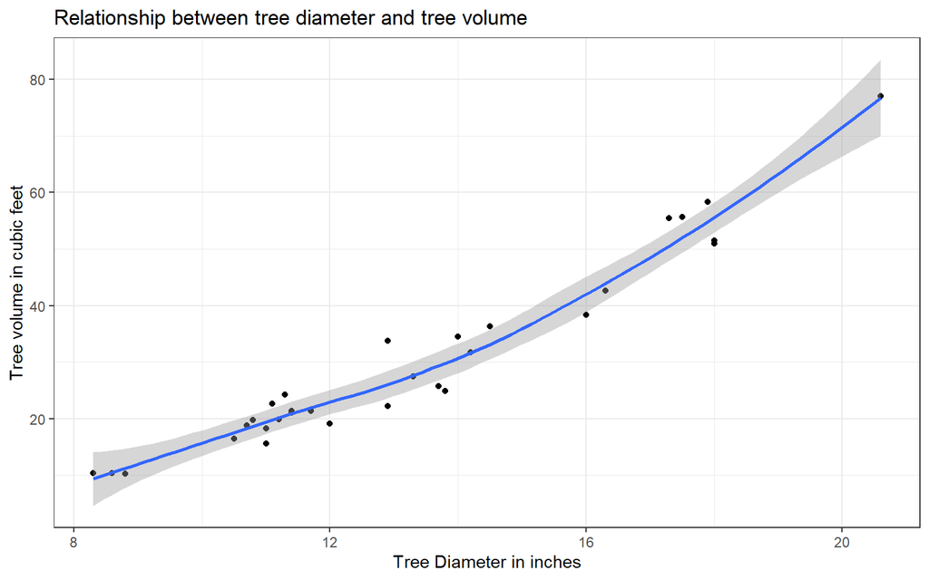

```r
trees %>%
  ggplot(aes(diameter, volume)) +
  geom_point() +
  geom_smooth() +
  labs(x = "Tree Diameter in inches",
       y = "Tree volume in cubic feet",
       title = "Relationship between tree diameter and tree volume") +
  theme_bw()
```

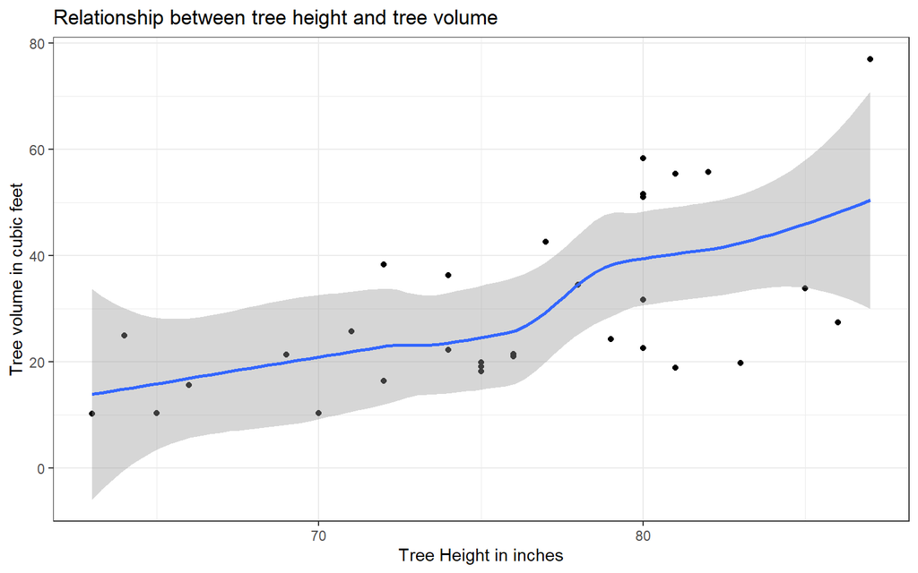

```r
trees %>%
  ggplot(aes(height, volume)) +
  geom_point() +
  geom_smooth() +
  labs(x = "Tree Height in inches",
       y = "Tree volume in cubic feet",
       title = "Relationship between tree height and tree volume") +
  theme_bw()
```

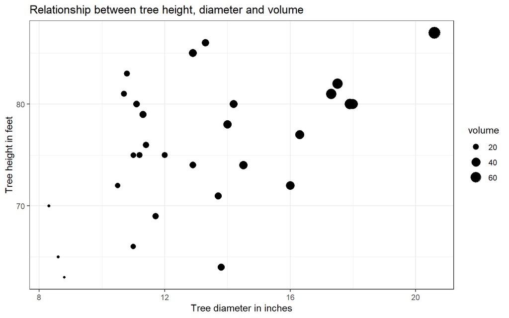

```r
trees %>%
  ggplot(aes(diameter, height, size = volume)) +
  geom_point() +
  labs(x = "Tree diameter in inches",
       y = "Tree height in feet",
       title = "Relationship between tree height, diameter and volume") +
  theme_bw()
```

THe plots above show a strong but non linear relationship between both height and diameter on volume.

We are going to fit the following model:

$$log(E(\text{volume}_i)) = f_1(\text{height}_i)
+ f_2(\text{diameter}_i) \text{ where } \text{volume}_i \sim \text{Gamma}$$

The functions $f_1$ and $f_2$ are smooth functions. The degree of smoothness will be estimated within certain limits using the `gam()` function from the `mgcv` package:

```r
model_1 <- gam(volume ~ s(height) + s(diameter),
               family = Gamma(link=log),
               data = trees)

# model summary
summary(model_1)
```

```
##
## Family: Gamma
## Link function: log
##
## Formula:
## volume ~ s(height) + s(diameter)
##
## Parametric coefficients:
##             Estimate Std. Error t value Pr(>|t|)
## (Intercept)  3.27570    0.01492   219.6   <2e-16 ***
## ---
## Signif. codes:  0 '***' 0.001 '**' 0.01 '*' 0.05 '.' 0.1 ' ' 1
##
## Approximate significance of smooth terms:
##               edf Ref.df      F  p-value
## s(height)   1.000  1.000  31.32 7.07e-06 ***
## s(diameter) 2.422  3.044 219.28  < 2e-16 ***
## ---
## Signif. codes:  0 '***' 0.001 '**' 0.01 '*' 0.05 '.' 0.1 ' ' 1
##
## R-sq.(adj) =  0.973   Deviance explained = 97.8%
## GCV = 0.0080824  Scale est. = 0.006899  n = 31
```

The summary method displays:

- The family and link functions
- The formula for the model we fit
- The estimated parametric coefficients (i.e just the intercept in this case)
- For each smoothing function, the effective degrees of freedon (edf).
  - For height, 1 edf, essentially a straigt line
  - for diameter, a smooth curve with 2.4 degrees of freedom.

The total degrees of freem for the model is the sum of the edf’s plus one for the model intercept.

There are several ways to plot the smoothed functions from the fitted object. We will highlight two methods here:

- Using the default plot method. This generates plots using R’s base graphics
- Using the `plot_smooths()` function from the tidymv package

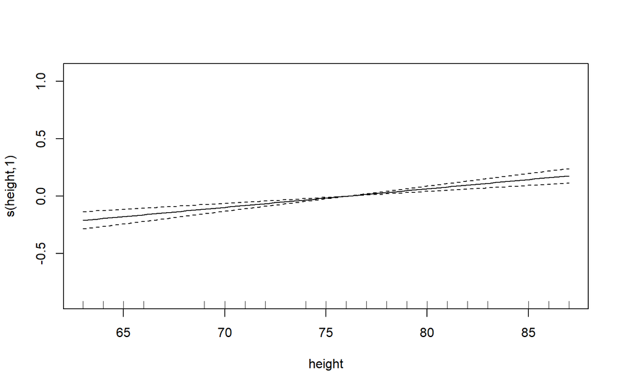

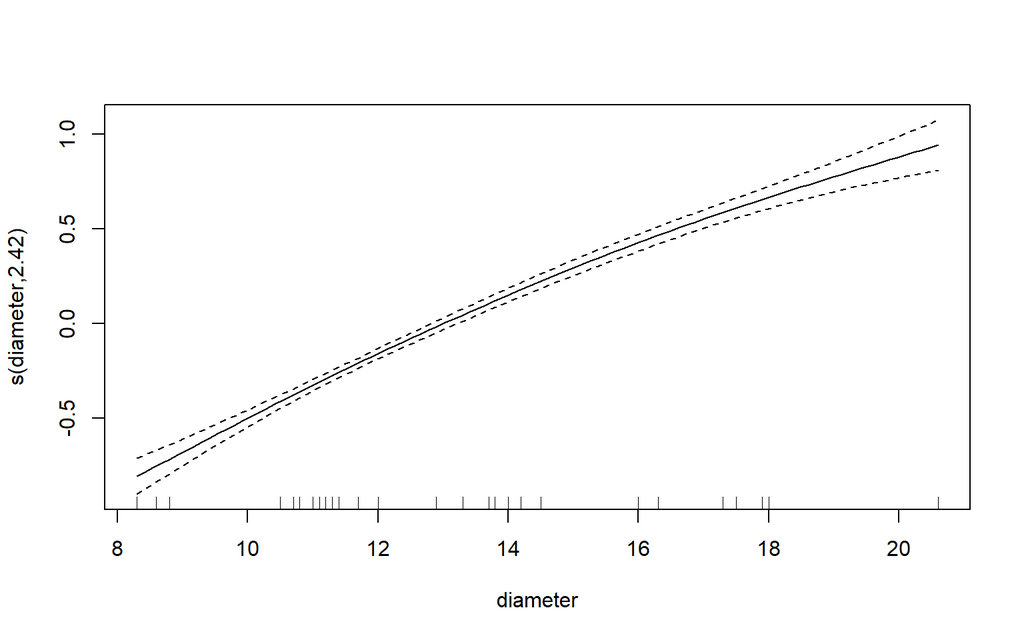

```r
library(tidymv)

# model plots using base R graphics
plot(model_1)
```

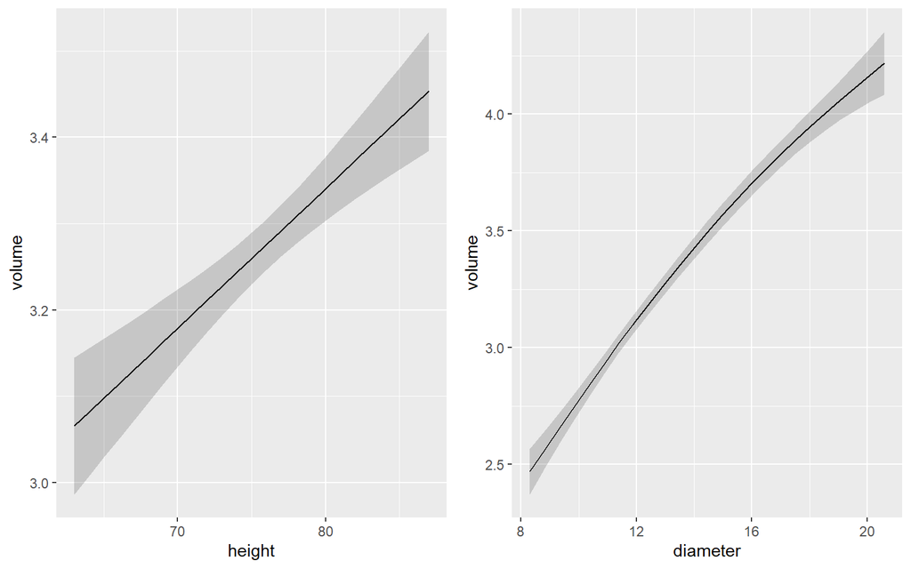

```r
p1 <- plot_smooths(
    model = model_1,
    series = height
)

p2 <- plot_smooths(
    model = model_1,
    series = diameter
)

cowplot::plot_grid(p1, p2)
```

Both methods create similar plots. The choice depends on coding standards/preferences and taste. We see that the effect of height on volume is essentially linear while there is a slight curve in the relationship beween diameter and volume. Both plots display 95% confidence intervals.